# Data Analysis and Visualization in R (IN2339)

Case Study

Aditi Arora*, Smarth Bakshi*, Ishan Bhattacharya*, Francisca Andrea Lagos López

2022-01-19

## Motivation

Open to the Mediterranean Sea and famous for Gaudí and his modernist architecture, Barcelona is revealed as one of the most important European capitals. The city is a focus of new trends in the world of culture, fashion and gastronomy. It combines the creativity of its artists and designers with respect and care for the traditional places of all time. In it, the charm and pause of its historic center, the avant-garde of its most modern neighborhoods and the urban rhythm of one of the most visited cities in the world coexist.

Notwithstanding the foregoing, is Barcelona a good place to migrate? In the following report, an analysis of the allocation of its inhabitants will be carried out, in particular of the immigrants who have decided to settle there. Literature widely reveals allocation patterns for immigrants taking into account socio demographic variables, like education, salary, age of arrival to the country, sex, duration of residence, local language proficiency, ethnicity and so on. In this case study, the objective is to glimpse if there is any immigrant allocation pattern with respect to the inherent characteristics of each of the 73 neighborhoods of the city of Barcelona, such as connectivity, rate of accidents, unemployment, life expectancy, population, etc.

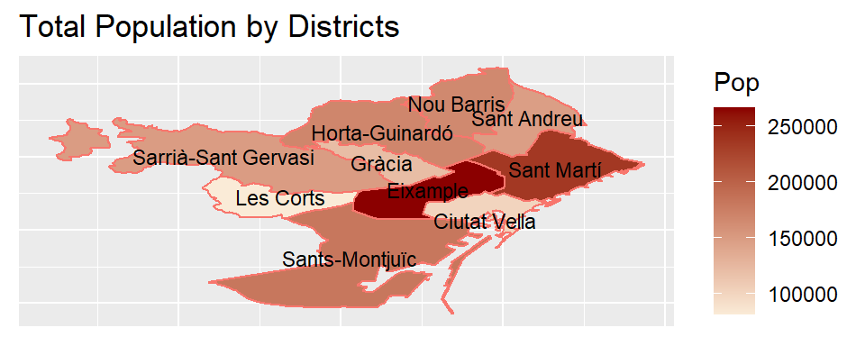

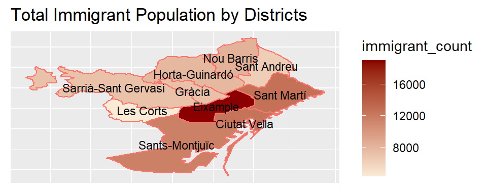

As we can see the district Eixample seems to have the highest immigrant population. This makes sense because from the population heatmap we can see that Eixample also has the highest population of all districts. Since this district has the city center, the data makes sense. Each district contains a number of neighbourhoods(a total of 73). In the following sections we will analyse certain variables at the neighbourhood level and try to see which of them are good indicators for high immigrant population.

## Data Preparation

In this section, the needed data preparation steps required for the analysis is performed. Unnecessary chunk codes are omitted in the compiled pdf-file. First of all, the actual allocation of the immigrants in the city is revealed, for which the “immigrants_by_nationality.csv” file was used. Due to the lack of data and the impossibility to differentiating them, all types of migrations were considered, including the internal one, even when this group represents 36.32% of all migrations data in 2017.

The data preparation steps for the different variables are as follows :

1. Accidents - The accidents.csv file contains accidents from the year 2017 along with details like neighbourhood, district and time. For our purposes only the number of accidents per district is required. Along with this the immigrant population is obtained from the immigrants_by_nationality.csv file. It contains the number of immigrants per neighbourhood for different years. Only 2017 data was considered for the accidents. Since areas with higher population would have higher accidents, the number of accidents was normalised using the total population of that neighbourhood and accidents per 1000 people were used for each neighbourhood for analysis.

2. Unemployment - The unemployment.csv and population.csv contains the number of unemployed individuals and population at districts and neighborhood level for the years 2013 - 2017 and the immigrant_emigrants_age consists of immigrants data for the years 2015-2017. The registered unemployed data at neighborhood level for the years 2015-17 is extracted and merged with neighborhood’s population data for the same time period. The resultant table is then merged with immigrants data at neighborhood level, also the unemployment is then normalized by population and consequently used for analysis and visualization.

3. Connectivity - For understanding the connectivity of each neighborhood, the “bus_stop.csv” file was used. After tidying up missing or mistaken values, and deleting duplicate ones, the final count of bus stops per neighborhood was calculated. For counting the number of bus stop per area, just the “Day bus stop” and “Night bus stop” variables were considered and sum up in the “dayandnigth_count” column, leaving appart the “Airport bus stop” and “Bus station” ones because they are just a few observations and do not really impact in the daily connectivity of the hood.

4. Life Expectancy - The life_expectancy.csv file contains life expectancy data for different neighbourhoods of Barcelona. For our purpose, we have taken the mean life expectancy per neighbourhood. To get the mean life expectancy, we have taken the average of life expectancy over the years 2006-2014. We have further taken the average of male and female population for each neighbourhood. To achieve this we have used melting and casting operations on original data table.

## Data Analysis

Analysis on number of bus stops,accidents,number of unemployed people and life expectancy per neighbourhood in relation to the immigrant population. For each variable the p value using spearman correlation test is given. The reason spearman correlation is used is because we observed that the immigrant count per neighbourhood does not follow a Gaussian distribution(figure below). For all the tests, the null hypothesis is as follows : H0 : There is no correlation between the variable and the immigrant count.

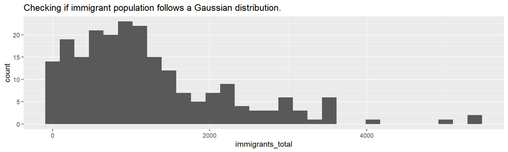

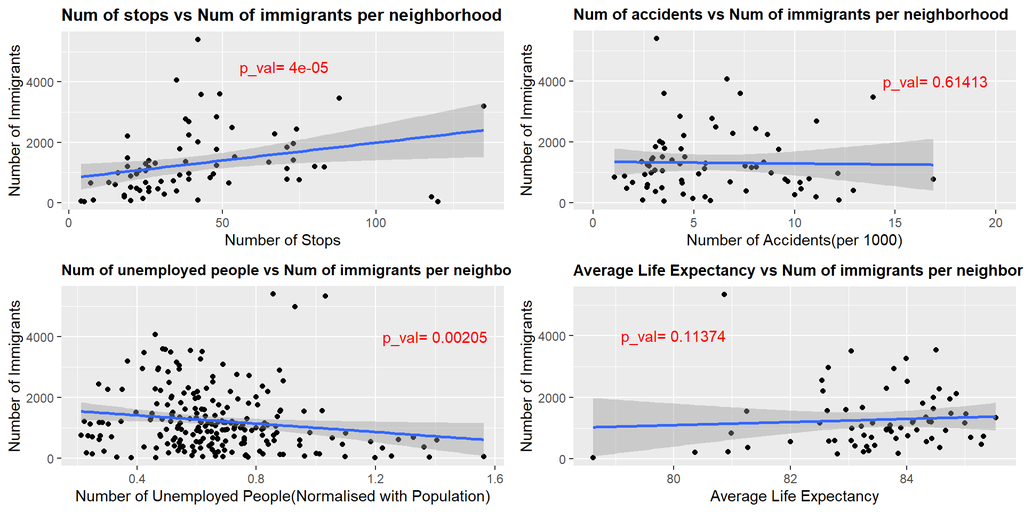

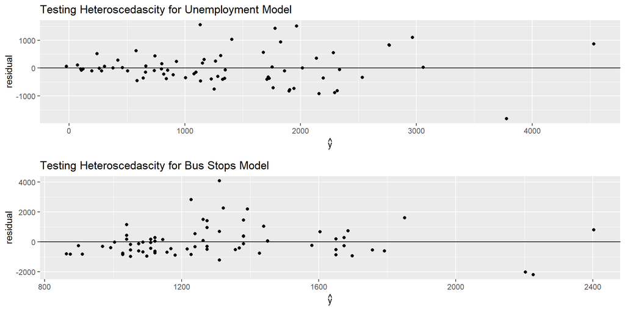

For both of the models, the variance of residuals is not constant and hence the resultant models will not be very effective. Nevertheless, on going ahead with the linear models we obtain the following analysis.

```
## Analysis of Variance Table
##
## Model 1: immigrant_count.x ~ dayandnight_count
## Model 2: immigrant_count.x ~ unemployment + dayandnight_count
##   Res.Df      RSS Df Sum of Sq      F    Pr(>F)
## 1     70 75164197
## 2     69 23068968  1  52095229 155.82 < 2.2e-16 ***
## ---
## Signif. codes:  0 '***' 0.001 '**' 0.01 '*' 0.05 '.' 0.1 ' ' 1
```

```
## Analysis of Variance Table
##
## Model 1: immigrant_count.x ~ unemployment
## Model 2: immigrant_count.x ~ unemployment + dayandnight_count
##   Res.Df      RSS Df Sum of Sq      F  Pr(>F)
## 1     70 24877107
## 2     69 23068968  1   1808139 5.4082 0.02299 *
## ---
## Signif. codes:  0 '***' 0.001 '**' 0.01 '*' 0.05 '.' 0.1 ' ' 1
```

## Conclusion

From the performed analysis we conclude that unemployment and bus stops(connectivity) do have some correlation with the number of immigrants in a neighbourhood. In the case of unemployment the correlation(-0.207) tells us that immigrants do tend to live in neighbourhoods with better employment numbers. For the bus stops we see a positive correlation(0.463) which makes sense because of ease of transport in well connected neighbourhoods. This would be particularly important for immigrants who rely heavily on public transport as compared to private vehicles.

For accidents we see that there is not much correlation, negative or positive, with immigrant population. This could imply that immigrants don’t necessarily care about these numbers and are more focused on factors like cost of living and connectivity. Our assumption was that better life expectancy could relate to better health services or higher safety in a neighbourhood. It seems that this is not a contributing factor in the distribution of immigrants in Barcelona.

Some of the shortcomings of our analysis are the lack of data regarding factors like cost of living which would perhaps have had a significant correlation with the immigrants population.

## References

For creating the district maps, shapefiles for Barcelon were obtained from https://opendata-ajuntament.barcelona.cat/data/en/dataset.